# Naive_bayesV3

Dan Johnson

12/18/2018

# Permutations of Naive Bayes (NB) Method

I based the original version on this source web site [https://rpubs.com/Billyhansen6/318412]. Version 1 can correctly identify sub-categories of comments ~80% of the time. This is better than the inter-rater reliability of two human raters, but still low. This notebook documents tests of various permutations of the NB method including:

- Different pre-processing methods: stemmed versus unstemmed, numbers removed vs. not, etc.
- Comparing n-grams rather than single words
- Pair-wise comparison versus comparing multiple groups simultaneously
- Modifying the variables within the NB analysis itself.

## Starting Version 1.0

Rows 22 to 230 of the code are the original starting version.

```r
library(tidyverse)
```

```r
library(tidytext)
library(dplyr)
library(tidyr)
library(ggplot2)
library(scales)
library(tm)
library(SnowballC)
library(wordcloud)
library(e1071)
library(gmodels)
library(readr)
```

```r
#Read in CSV file named "coded_full_comments_dataset_Spring18anon.csv".
base_data <- read_csv(file='data/coded_full_comments_dataset_Spring18anon.csv')
#Isolate rows to compare.
frequency_writing <- filter(base_data,code.subject=="2. Writing Quality"|code.subject=="3. Technical and Scientific"|code.subject=="4. Logic and Thinking")

#Reduce larger dataframe to 2 required columns of data, and put columns in order needed.
sms_raw2 <- frequency_writing %>% select(23,22)

#Rename the columns.
names(sms_raw2)[1] <- "type"
names(sms_raw2)[2] <- "text"

#Simplify coding terms
sms_raw2[,1] <- ifelse(sms_raw2[,1] == "2. Writing Quality", "2_Writing", ifelse(sms_raw2[,1] == "3. Technical and Scientific", "3_Technical", ifelse(sms_raw2[,1] == "4. Logic and Thinking","4_Logic",99)))

#Change "type" element from character to a factor for analysis.
sms_raw2$type <- factor(sms_raw2$type)
str(sms_raw2$type)
```

```
##  Factor w/ 3 levels "2_Writing","3_Technical",..: 2 1 2 2 2 2 3 3 3 2 ...
```

```r
table(sms_raw2$type)
```

```
##
##   2_Writing 3_Technical     4_Logic
##        2578        5409        1142
```

```r
#library(tm)
##Text Transformation using "tm" package in R to create a volitile coprus that contains the "text" vector from our data frame.
sms_corpus2 <- VCorpus(VectorSource(sms_raw2$text))
print(sms_corpus2)
```

```
## <<VCorpus>>
## Metadata:  corpus specific: 0, document level (indexed): 0
## Content:  documents: 9129
```

```r
#Check out the first few messages in the new corpus, which is basically a list that can be manipulated with list operations.
inspect(sms_corpus2[1:3])
```

```
## <<VCorpus>>
## Metadata:  corpus specific: 0, document level (indexed): 0
## Content:  documents: 3
##
## [[1]]
## <<PlainTextDocument>>
## Metadata:  7
## Content:  chars: 15
##
## [[2]]
## <<PlainTextDocument>>
## Metadata:  7
## Content:  chars: 31
##
## [[3]]
## <<PlainTextDocument>>
## Metadata:  7
## Content:  chars: 70
```

```r
#Use "as.character" function to see what a message looks like.
as.character(sms_corpus2[[3]])
```

```
## [1] "Is this the most concise way to communicate no significant difference?"
```

In order to standardize the messages, the data set must be tranformed to all lower case letters. The words “Free”, “free”, and “FREE” should all be treated as the same word. Use the “tm_map”" funtion in R, and use the “content_transformer” function to transform the text.

```r
sms_corpus_clean2 <- tm_map(sms_corpus2, content_transformer(tolower))
```

Look at third message again to see if our data was transformed.

```r
as.character(sms_corpus2[[3]])
```

```
## [1] "Is this the most concise way to communicate no significant difference?"
```

```r
as.character((sms_corpus_clean2[[3]]))
```

```
## [1] "is this the most concise way to communicate no significant difference?"
```

This removes numbers. **May not want to do.**

```r
sms_corpus_clean2 <- tm_map(sms_corpus_clean2, removeNumbers)
```

Stopword removal takes out words that appear often but don’t contribute to our objective. These words include “to”, “and”, “but” and “or”. **One of variables to test out.**

```r
sms_corpus_clean2 <- tm_map(sms_corpus_clean2, removeWords, stopwords())
```

Remove punctuation as well using the “removePunctuation” function. **Try not doing this.**

```r
sms_corpus_clean2 <- tm_map(sms_corpus_clean2, removePunctuation)

as.character((sms_corpus_clean2[[3]]))
```

```
## [1] "    concise way  communicate  significant difference"
```

Perform “stemming” to the text data to strip the suffix from words. **Try NOT doing this.**

```r
#library(SnowballC)
sms_corpus_clean2 <- tm_map(sms_corpus_clean2, stemDocument)
```

And now the final step in text mining is to remove white space from the document.

```r
sms_corpus_clean2 <- tm_map(sms_corpus_clean2, stripWhitespace)
```

```r
as.character(sms_corpus_clean2[[3]])
```

```
## [1] "concis way communic signific differ"
```

Perform tokenization using the “DocumentTermMatrix” function. This creates a matrix in which the rows indicate documents (SMS messages in this case) and the columns indicate words. It should be noted that the “DocumentTermMaxtrix” function has the power to do all of the text mining above in one command.

```r
sms_dtm2 <- DocumentTermMatrix(sms_corpus_clean2)
```

## Data Preparation

Split data into training and testing sets, so that after Naive Bayes spam filter algorithm is built it can be applied to unseen data. Divide our data set into 75% training and 25% testing.

```r
.75 * 9129
```

```
## [1] 6846.75
```

```r
.25 * 9129
```

```
## [1] 2282.25
```

This code assumes comments are random. **Probably want to try randomizing them.**

```r
sms_dtm_train2 <- sms_dtm2[1:6846, ]
sms_dtm_test2 <- sms_dtm2[6847:9129, ]
```

Save vectors labeling rows in the training and testing vectors

```r
sms_train_labels2 <- sms_raw2[1:6846, ]$type
sms_test_labels2 <- sms_raw2[6847:9129,]$type
```

Make sure that the proportion of each sub-category is similar in the training and testing data set.

```r
prop.table(table(sms_train_labels2))
```

```
## sms_train_labels2
##   2_Writing 3_Technical     4_Logic
##   0.2854221   0.5911481   0.1234297
```

```r
prop.table(table(sms_test_labels2))
```

```
## sms_test_labels2
##   2_Writing 3_Technical     4_Logic
##   0.2733246   0.5965834   0.1300920
```

## Visualization

Create a wordcloud of the frequency of the words in the dataset using the package “wordcloud”.

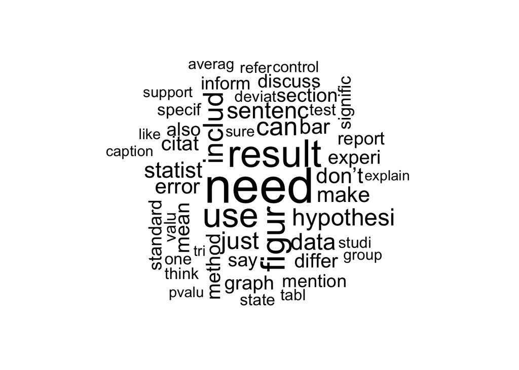

```r
#library(wordcloud)
wordcloud(sms_corpus_clean2, max.words = 50, random.order = FALSE)
```

Compare wordclouds between 3 groups.

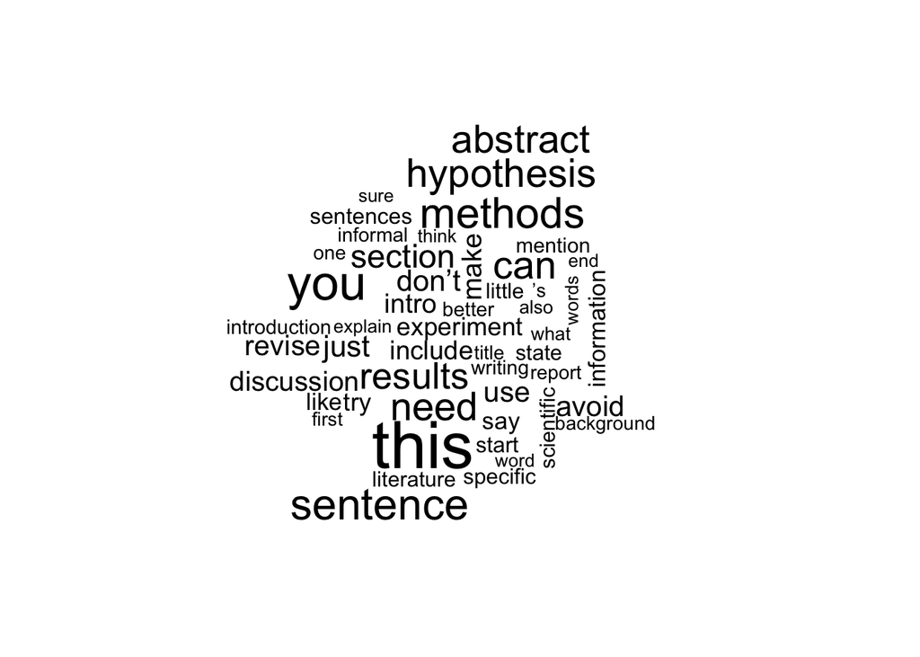

```r
TWO <- subset(sms_raw2, type == "2_Writing")
THREE <- subset(sms_raw2, type == "3_Technical")
FOUR <- subset(sms_raw2, type == "4_Logic")

wordcloud(TWO$text, max.words = 50, scale = c(3, 0.5))
```

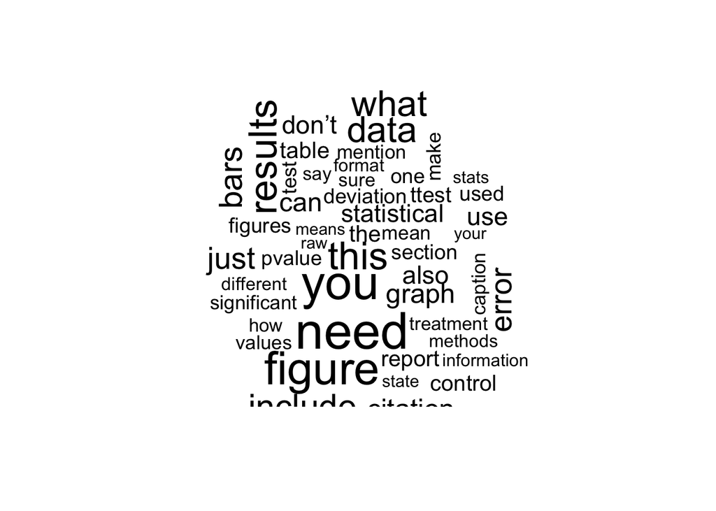

```r
wordcloud(THREE$text, max.words = 50, scale = c(3, 0.5))
```

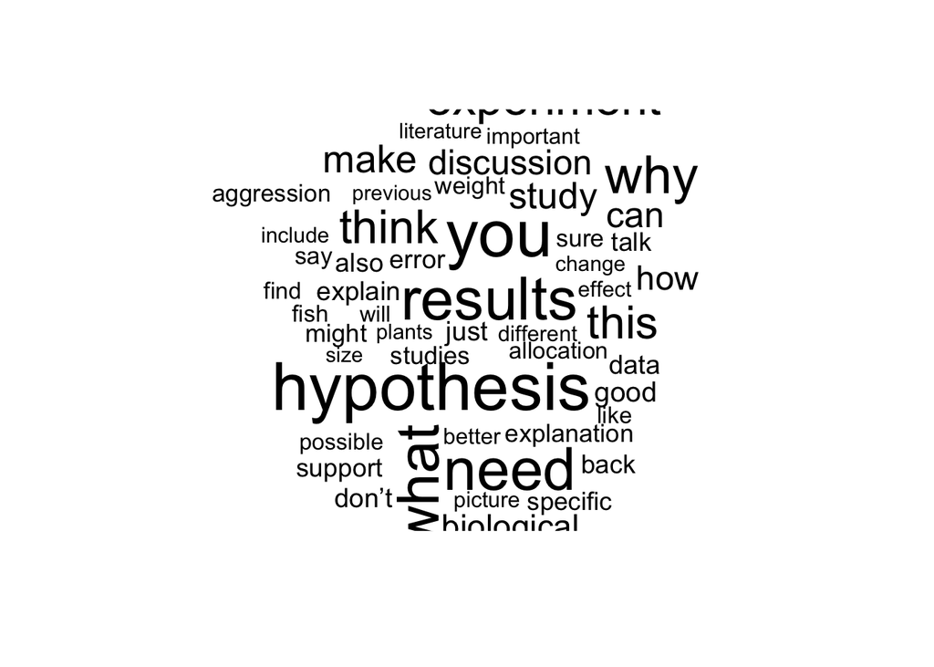

```r
wordcloud(FOUR$text, max.words = 50, scale = c(3, 0.5))
```

## Preparation for Naive Bayes

Remove words from the matrix that appear less than 5 times.

```r
sms_freq_words2 <- findFreqTerms(sms_dtm_train2, 5)
str(sms_freq_words2)
```

```
##  chr [1:1034] "’ll" "’re" "’ve" "“correct”" "“figur" "“group" ...
```

Limit our Document Term Matrix to only include words in the sms_freq_vector. We want all the rows, but we want to limit the column to these words in the frequency vector.

```r
sms_dtm_freq_train2 <- sms_dtm_train2[ , sms_freq_words2]
sms_dtm_freq_test2 <- sms_dtm_test2[ , sms_freq_words2]
```

The naive bayes classifier works with categorical features, so we need to convert the matrix to “yes” and “no” categorical variables. To do this we’ll build a convert_counts function and apply it to our data.

```r
convert_counts2 <- function(x) {
  x <- ifelse(x > 0, "Yes", "No")
}
```

This replaces values greater than 0 with yes, and values not greater than 0 with no. Let’s apply it to our data.

```r
sms_train2 <- apply(sms_dtm_freq_train2, MARGIN = 2, convert_counts2)
sms_test2 <- apply(sms_dtm_freq_test2, MARGIN = 2, convert_counts2)
```

The resulting matrixes will be character type, with cells indicating “yes” or “no” if the word represented by the column appears in the message represented by the row.

## Train Model, Predict, Evaluate

Use the e1071 package to implement Naive Bayes algorithm on the data, and predict whether a message is likely to be in group TWO, THREE, or FOUR. Evaluate the prediction with the actual data using a crosstable from the gmodels package.

```r
#library(e1071)
#library(gmodels)
sms_classifier2 <- naiveBayes(sms_train2, sms_train_labels2)
sms_test_pred2 <- predict(sms_classifier2, sms_test2)
CrossTable(sms_test_pred2, sms_test_labels2, prop.chisq = FALSE, prop.t = FALSE, dnn = c('predicted', 'actual'))
```

```
##
##
##    Cell Contents
## |-------------------------|
## |                       N |
## |           N / Row Total |
## |           N / Col Total |
## |-------------------------|
##
##
## Total Observations in Table:  2283
##
##
##              | actual
##    predicted |   2_Writing | 3_Technical |     4_Logic |   Row Total |
## -------------|-------------|-------------|-------------|-------------|
##    2_Writing |         457 |         104 |          63 |         624 |
##              |       0.732 |       0.167 |       0.101 |       0.273 |
##              |       0.732 |       0.076 |       0.212 |             |
## -------------|-------------|-------------|-------------|-------------|
##  3_Technical |         108 |        1198 |          43 |        1349 |
##              |       0.080 |       0.888 |       0.032 |       0.591 |
##              |       0.173 |       0.880 |       0.145 |             |
## -------------|-------------|-------------|-------------|-------------|
##      4_Logic |          59 |          60 |         191 |         310 |
##              |       0.190 |       0.194 |       0.616 |       0.136 |
##              |       0.095 |       0.044 |       0.643 |             |
## -------------|-------------|-------------|-------------|-------------|
## Column Total |         624 |        1362 |         297 |        2283 |
##              |       0.273 |       0.597 |       0.130 |             |
## -------------|-------------|-------------|-------------|-------------|
##
##
```

Show the 5 most frequent words in the data:

```r
sack2 <- TermDocumentMatrix(sms_corpus_clean2)
pack2 <- as.matrix(sack2)
snack2 <- sort(rowSums(pack2), decreasing = TRUE)
hack2 <- data.frame(word = names(snack2), freq=snack2)
head(hack2, 5)
```

```
##          word freq
## need     need 1350
## result result 1007
## use       use  896
## figur   figur  852
## includ includ  677
```

And the 5 most frequent words from each class:

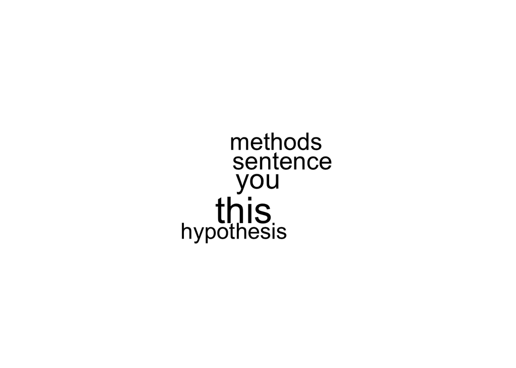

```r
wordcloud(TWO$text, max.words = 5, scale = c(3, 0.5))
```

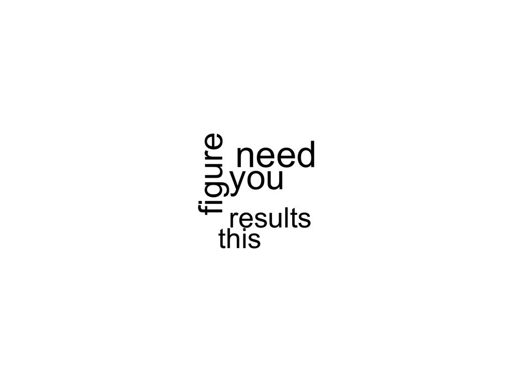

```r
wordcloud(THREE$text, max.words = 5, scale = c(3, 0.5))
```

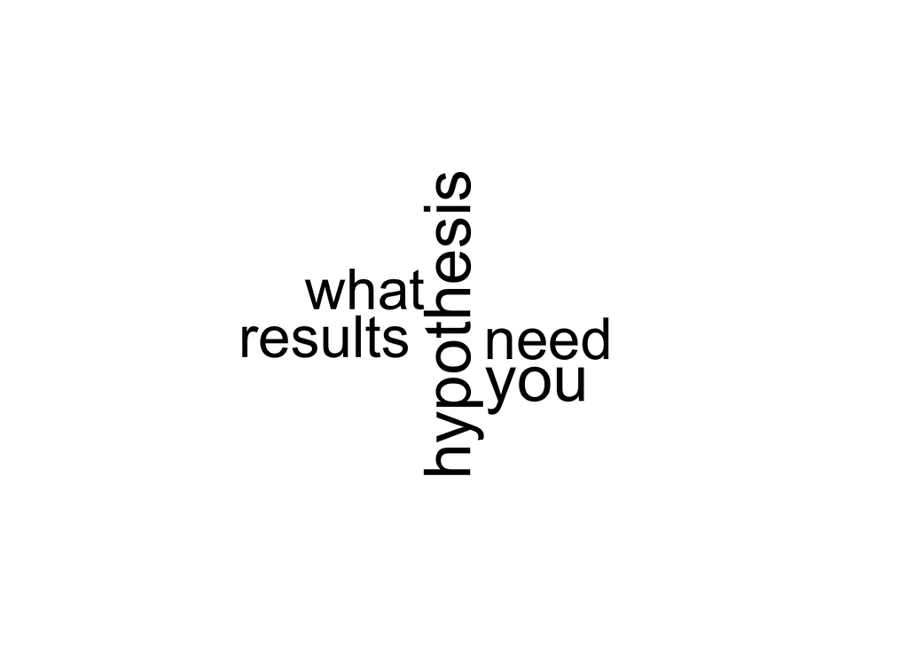

```r
wordcloud(FOUR$text, max.words = 5, scale = c(3, 0.5))
```